# Workshop 11

# Modelos de clasificacion

## Regresión logistica

Normalmente la regresión logística siempre es un buen lugar para empezar a tantear tu ejercicio predicitvo. Side note: En el caso del credit scoring, es el método predilecto porque los módelos están forzados a ser transparentes. Si Moncho ve que su Score es 25, el tiene derecho de escribirle al equipo de modelos y preguntarles cúal de sus carácterísticas hizo que tuviera un score tan bajo.

```r
# fijemos un modelo de high sale y... ¿Todas las variables?
## Si quieren veamos la data con calma y
logit_1<-glm(high_sale~. , data=ames_train, family = binomial(link="logit"))
# Quizas no sea lo mejor, corremos el riesgo de over-fitting a los datos de entrenamiento
## Idea: Podemos usar el método lasso que vimos la clase pasada para seleccionar las variables con mas señal y menos ruido
## Volveremos a usar la libreria glm
```

```r
# Pre-processing
# Debemos normalizar las variables que queremos que esten en el modelo. En este caso, implica ponerlas en un formato matricial especial.
# Recuerda que los [] son para seleccionar componentes de distintos objetos en R.
# Genericamente matriz[1:3,1:2] un comando asi te devolvera las 3 perimeras filas y las 2 primeras columnas de una matriz
# glmnet::
X_train <- model.matrix(high_sale ~ ., data = ames_train)[, -1]
y_train <- ames_train$high_sale

X_test <- model.matrix(high_sale ~ ., data = ames_test)[, -1]
y_test <- ames_test$high_sale

# LOGIT LASSO -----
fit_lasso <- glmnet::cv.glmnet(x = X_train, y = y_train,
                       alpha = 1, nfolds = 5,
                       family = "binomial", type.measure="auc")

glmnet::assess.glmnet(fit_lasso, newx = X_train, newy = y_train)
```

```
## $deviance
## lambda.1se
##  0.2820435
## attr(,"measure")
## [1] "Binomial Deviance"
##
## $class
## lambda.1se
## 0.05070697
## attr(,"measure")
## [1] "Misclassification Error"
##
## $auc
## [1] 0.9860144
## attr(,"measure")
## [1] "AUC"
##
## $mse
## lambda.1se
## 0.07597939
## attr(,"measure")
## [1] "Mean-Squared Error"
##
## $mae
## lambda.1se
##  0.2053231
## attr(,"measure")
## [1] "Mean Absolute Error"
```

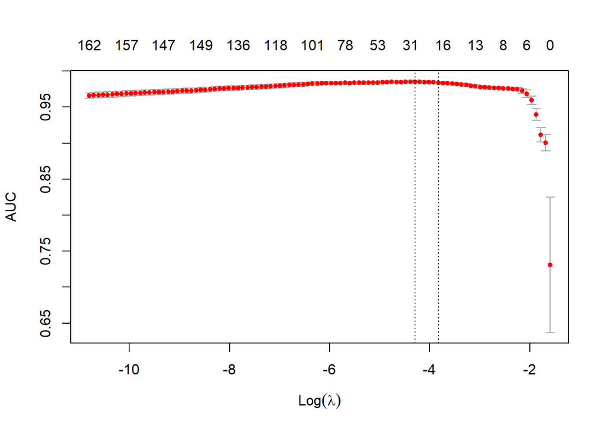

```r
# LASSO OUTPUTS ---
# Paremos un segundo para ver que es esto ?cv.glmnet

# Grafico
plot(fit_lasso) # Eje x muestra todos los lamba simulados, y es el AUC, arriba esta la cantidad de variables seleccionadas en cada modelo, la primera linea muestra el lambda de minimo AUC
```

```r
# Componentes
# este es un listado de la info contenida en el objeto fit_lasso
summary(fit_lasso)
```

```
##            Length Class  Mode
## lambda     100    -none- numeric
## cvm        100    -none- numeric
## cvsd       100    -none- numeric
## cvup       100    -none- numeric
## cvlo       100    -none- numeric
## nzero      100    -none- numeric
## call         7    -none- call
## name         1    -none- character
## glmnet.fit  13    lognet list
## lambda.min   1    -none- numeric
## lambda.1se   1    -none- numeric
## index        2    -none- numeric
```

```r
# Resultados
# asi podemos extraer un data.frame con los coeficientes resultantes de la mejor estimacion
chosen_variables<-enframe(glmnet::coef.glmnet(fit_lasso, s="lambda.min")[,1])

chosen_variables %>%
  filter(value!=0) %>%
  arrange(desc(value))
```

```
## # A tibble: 27 x 2
##    name                           value
##    <chr>                          <dbl>
##  1 Exterior_1stPreCast            1.97
##  2 Overall_QualExcellent          1.90
##  3 Overall_QualVery_Good          1.31
##  4 NeighborhoodNorthridge         1.31
##  5 Bsmt_Full_Bath                 0.583
##  6 NeighborhoodNorthridge_Heights 0.541
##  7 Fireplaces                     0.423
##  8 Bsmt_ExposureGd                0.415
##  9 Land_ContourLow                0.398
## 10 Pool_QCGood                    0.309
## # ... with 17 more rows
```

## Arboles de decision (CART)

Siguiendo esta misma lógica, los arboles de regresión nos dan predicciones basadas en aquellas variables con mayor señal.

```r
#Decision Tree or Regression Tree
fit_tree <- rpart(high_sale ~ .,
                      data=ames_train,
                  control = rpart.control(xval = 10)) ## this sets the number of folds for cross validation.

fit_tree #Text Representation of Tree
```

```
## n= 2051
##
## node), split, n, deviance, yval
##       * denotes terminal node
##
##  1) root 2051 272.132600 0.15748420
##    2) Overall_Qual=Very_Poor,Poor,Fair,Below_Average,Average,Above_Average,Good 1705  71.700880 0.04398827
##      4) Gr_Liv_Area< 2011 1559  22.660680 0.01475305 *
##      5) Gr_Liv_Area>=2011 146  33.479450 0.35616440
##       10) Neighborhood=North_Ames,College_Creek,Old_Town,Edwards,Gilbert,Sawyer,Northwest_Ames,Sawyer_West,Mitchell,Brookside,Crawford,Iowa_DOT_and_Rail_Road,Timberland,Stone_Brook,South_and_West_of_Iowa_State_University,Clear_Creek,Meadow_Village 126  23.873020 0.25396830
##         20) Total_Bsmt_SF< 1381 102  14.166670 0.16666670 *
##         21) Total_Bsmt_SF>=1381 24   5.625000 0.62500000 *
##       11) Neighborhood=Somerset,Northridge_Heights,Northridge,Veenker 20   0.000000 1.00000000 *
##    3) Overall_Qual=Very_Good,Excellent,Very_Excellent 346  70.242770 0.71676300
##      6) Gr_Liv_Area< 1597.5 81  15.061730 0.24691360
##       12) Kitchen_Qual=Good,Typical 69   8.550725 0.14492750
##         24) Bsmt_Full_Bath< 0.5 36   0.000000 0.00000000 *
##         25) Bsmt_Full_Bath>=0.5 33   6.969697 0.30303030
##           50) Total_Bsmt_SF< 1473.5 26   2.653846 0.11538460 *
##           51) Total_Bsmt_SF>=1473.5 7   0.000000 1.00000000 *
##       13) Kitchen_Qual=Excellent 12   1.666667 0.83333330 *
##      7) Gr_Liv_Area>=1597.5 265  31.833960 0.86037740
##       14) Total_Bsmt_SF< 1001 29   7.241379 0.48275860
##         28) Neighborhood=Old_Town,Northwest_Ames,Sawyer_West,Northridge,Veenker 9   0.000000 0.00000000 *
##         29) Neighborhood=Somerset,Northridge_Heights,Gilbert,Crawford,Timberland,Clear_Creek 20   4.200000 0.70000000 *
##       15) Total_Bsmt_SF>=1001 236  19.949150 0.90677970 *
```

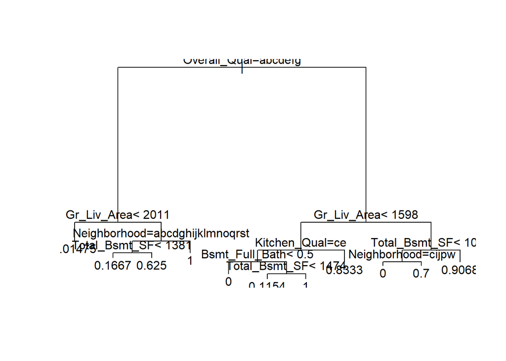

```r
plot(fit_tree) # plot tree
text(fit_tree) # add labels to tree
```

```r
printcp(fit_tree) # print complexity parameter table using cross validation (xerror)
```

```
##
## Regression tree:
## rpart(formula = high_sale ~ ., data = ames_train, control = rpart.control(xval = 10))
##
## Variables actually used in tree construction:
## [1] Bsmt_Full_Bath Gr_Liv_Area    Kitchen_Qual   Neighborhood   Overall_Qual
## [6] Total_Bsmt_SF
##
## Root node error: 272.13/2051 = 0.13268
##
## n= 2051
##
##          CP nsplit rel error  xerror     xstd
## 1  0.478403      0   1.00000 1.00129 0.041578
## 2  0.085793      1   0.52160 0.52277 0.032987
## 3  0.057181      2   0.43580 0.44698 0.033867
## 4  0.035301      3   0.37862 0.39943 0.028387
## 5  0.017801      4   0.34332 0.37889 0.029447
## 6  0.017063      5   0.32552 0.40295 0.030955
## 7  0.014998      6   0.30846 0.40517 0.031634
## 8  0.011176      7   0.29346 0.40770 0.032286
## 9  0.010835      8   0.28228 0.40821 0.032629
## 10 0.010000     10   0.26062 0.40755 0.032461
```

```r
#Generate predictions for test data
pred_tree <- predict(fit_tree, newdata=ames_test)
```

## Random forest

```r
#Two commands to implement random forests: randomForest() and ranger()
#ranger() is quicker

#Random Forest from 500 Bootstrapped Samples (ntree=500)
fit_forest <- randomForest(high_sale ~ .,
                               ntree=500,
                               importance=TRUE,
                               data=ames_train)
#Text Representation of Tree
head(getTree(fit_forest, 250, labelVar = TRUE) )
```

```
##   left daughter right daughter     split var split point status prediction
## 1             2              3  Overall_Qual       127.0     -3 0.17552413
## 2             4              5   Gr_Liv_Area      2060.5     -3 0.04219409
## 3             6              7   Gr_Liv_Area      1616.5     -3 0.73979592
## 4             8              9    Land_Slope         3.0     -3 0.01361868
## 5            10             11 Open_Porch_SF        25.5     -3 0.41880342
## 6            12             13  Exterior_1st     65271.0     -3 0.34259259
```

## Comparemos

```r
# Generate predictions for training data.
# Compare models with respect to how well they fit trianing

## predicciones
pred_logit <- predict(logit_1, newdata=ames_train, type="response")
```

```r
pred_lasso <- predict(fit_lasso, newx = X_train,  s = "lambda.min", type="response")
pred_cart <- predict(fit_tree, newdata=ames_train)
pred_forest <- predict(fit_forest, newdata=ames_train, type="response")

## Areas under the curve
auc_score_logit = auc(ames_train$high_sale, pred_logit)
auc_score_lasso = auc(ames_train$high_sale, pred_lasso)
auc_score_cart = auc(ames_train$high_sale, pred_cart)
auc_score_RF = auc(ames_train$high_sale, pred_forest)
## comparaciones
data.frame(auc_score_logit,
           auc_score_lasso,
           auc_score_cart,
           auc_score_RF
)
```

```
##   auc_score_logit auc_score_lasso auc_score_cart auc_score_RF
## 1             0.5       0.9885908        0.95285            1
```

```r
# Generate predictions for test data.
# Compare models with respect to how well they fit test

## predicciones
# pred_logit <- predict(logit_1, newdata=ames_test, type="response") # Dará problemas porque usa todas las variables. Pudiera resolverse estratificando las muestras, pero sabemos que este modelo no añade nada
pred_lasso <- predict(fit_lasso, newx = X_test,  s = "lambda.min", type="response")
pred_cart <- predict(fit_tree, newdata=ames_test)
pred_forest <- predict(fit_forest, newdata=ames_test, type="response")

## Areas under the curve
# auc_score_logit = auc(ames_test$high_sale, pred_logit)
auc_score_lasso = auc(ames_test$high_sale, pred_lasso)
auc_score_cart = auc(ames_test$high_sale, pred_cart)
auc_score_RF = auc(ames_test$high_sale, pred_forest)
## comparaciones
data.frame(
           auc_score_lasso,
           auc_score_cart,
           auc_score_RF
)
```

```
##   auc_score_lasso auc_score_cart auc_score_RF
## 1       0.9815493      0.9272798    0.9858804
```

## Enlaces de interés

[Kaggle.com](https://www.kaggle.com/): Concursos, data-sets y foros, relacionados a Machine Learning.

[Opportunity insigths:](https://opportunityinsights.org/) Datos del atlas de oportunidad, proyecto del profesor Raj Chetty sobre movilidad social con big data.

[Atlas de complejidad económica](https://atlas.cid.harvard.edu/) y [Metroverse](https://metroverse.cid.harvard.edu/): Acercamiento a los determinantes del crecimiento económico (y el cambio de la estructura productiva) aplicando de Machine Learning sobre datos de exportaciones y empleo.